# Multilevel Modeling Using R

Leandro Ledesma

2024-05-16

# Chapter 1: Introduction

### Brief overview of the importance for implementing multilevel modeling

The function of this document is to summarize several chapters from ‘Practical Multilevel Modeling Using R’ by Francis L. Huang. This textbook is tailor made to learn the basics of multilevel modeling (also known as hierarchical linear modeling, etc.) to run appropriate analyses in data that would be best explained from this type of modeling. Essentially, this model builds on multiple regression by introducing the categorization of variables into different levels. The most basic data structure that would require multilevel modeling is two levels, with level-1 units nested within higher-level groups or clusters. A clear example of this can be shown with predicting school performance. Level-1 units in this case could be related to students overall such as IQ, attendance, motivation, etc. For the level-2 units, it could be classes, since it is expected that teaching performance across classrooms would vary, which could also influence the level-1 outcome. It is important in this context to have classes as a level-2 unit in the model, because students within classrooms are more likely to perform similar to each other than other classrooms. Ignoring this fact by running a multiple regression (ignoring classifying variables into lower or higher-level units) would violate the assumption of independence (since in this cases the performance of one student is likely to predict the performance of another student) and will lead to incorrect parameter estimates. Thus, knowing when to use multilevel modeling will lead to better and more accurate results.

### Group-level and individual-level correlations are not the same

We know when we have hierarchical data because values of a predictor will be shared many subjects and values of another predictor will for the most part vary person from person. In this case, the former would be the level-2 unit and the latter would be the level-1 unit. One interesting finding from a study that analyzed the correlation between literacy rates and foreign born status is that the correlation between a level-1 predictor/outcome and a level-2 predictor/outcome respectively will not be the same. This is not always the case but it just so happens in this example that the level-1 correlation led to a positive relationship while the level-2 correlation (**ecological correlation**) led to a negative relationship- showing the opposite conclusion.

### Dangers of running a OLS multiple regression with the inclusion of level-2 group predictors

In your dataset, if you see a predictor value (such as group) that is greatly shared by subjects (aka the subjects are nested within this group category) and this predictor is included into a regular OLS multiple regression, then your results **will** be biased. This comes back to the idea that larger sample sizes will in the end make almost everything significant. The larger then n, the smaller than the standard errors become, which makes it easier to reject the null hypothesis when it was not supposed to be rejected (Type I error).

### Other reasons for using MLM (research questions)

# Chapter 2: The Unconditional Means Model

We first need to try to understand a bit about notation since more complicated versions of MLM will only build on this notation. We will be discussing the ‘level’ notation.

### Review of multiple regression notation

Below are the typical notations of a multiple regression. The first shows the notation of a multiple regression in the population (I think). Y represents the scores of the outcome variable and they are equal to the scores of X multiplied by a fixed constant (slope) plus another fixed constant (intercept) plus any error not accounted for in the model. The second notation shows an estimated multiple regression from sample data. In this case, $\hat{Y}$ represents the estimate scores of Y by the inputs of scores from X. The r, which represents error, is removed from this notation because we are interested in the estimated Y scores- its inclusion will just give us Y/the observed scores for the outcome variable.

$$\begin{align*}
Y = \beta_{0} + \beta_{1}X_{1} + r
\end{align*}$$

$$\begin{align*}
\hat{Y} = b_{1}X_{1} + a
\end{align*}$$

### Unconditional Means/Null Model

This is typically the first step when running a multilevel model analysis. Start by creating a model with no predictors whatsoever and then look at the variance of the outcome variable. This null model will have two functions, to 1) partition the variance into different levels and to 2) establish baseline levels of variance.

**Level 1 equation:** Below is an example of a regression without predictors (with additional information in the subscripts that is important). We have the outcome variable expressed as Y (aka the actual observed values for Y) which is equal to the intercept ($\beta_{0j}$) plus error ($r_{ij}$). In this case the intercept refers to the mean of the outcome variable, which is expressed as $\bar{Y}$. However, the subscripts are also very important because it changes the meaning of this a bit. The introduction of the subscript ‘i’ is nothing new and represents an individual’s score. The ‘j’ subscript changes the meaning quite a bit because it is a notation for group type. Thus, when we mentioned that the intercept would be the mean of the outcome variable ($\bar{Y}$), one would assume this would be the **grand mean** however that is not the case. Instead, this would correspond to the mean of the outcome variable ($\bar{Y}_{j}$) for group j. Additionally, the error ($r_{ij}$) also includes a ‘j’ subscript. This indicates that the error (residual- distance the observed values are from the fitted values) is dependent on the group mean of j as well.

$$\begin{align*}
Y_{ij} = \beta_{0j} + r_{ij}
\end{align*}$$

**Level 2 equation:** This includes notation that may be less familiar. It is written in the same format that a regression would be but has less common symbols. Starting from the left side, gamma with the two zeroes ($\gamma_{00}$) represents the **grand mean** of the outcome ($\bar{Y}$). This is pretty straight-forward, it takes the function of what a regular regression intercept would when predictors are absent. The second portion complicates things a bit further. $\mu_{0j}$ I think functions similarly to $r$ because it represents the distance the group of mean j is from the grand mean. We can see then that the addition of these two symbols for respective j groups leads to the outcome means of j. Ex: grand mean of Y + residuals of group mean from the grand mean = group means of Y.

$$\begin{align*}
\beta_{0j} = \gamma_{00} + \mu_{0j}
\end{align*}$$

**Combining equations:** We discuss the logic and specifics of the last two equations so we can merge them into one equation that represents multilevel modeling. The final product is the equation shown below. Starting from left to right, the goal of this model is to predict observed values of the outcome ($Y_{ij}$) for each individual in their respective ‘j’ group by taking the grand mean of the outcome ($\bar{Y}$) and adding two sets of residuals (no predictors). The first set of residuals (level-2) is the distance of the group mean j from the grand mean and the second set (level-1) is the distance of the observed value from the group mean of j. This can make more sense with the graph below.

$$\begin{align*}
Y_{ij} = \gamma_{00} + \mu_{0j} + r_{ij}
\end{align*}$$

**Visualizing the combined equation:** As mentioned, one reason for running a multilevel model is the ability to take the variance of the outcome variable ($Y$) and partitioning it into the individual-level and group-level variance. This can be seen in the plot below. We start with the grand mean ($\gamma_{00}$) represented by the dashed horizontal line going through the plot. The group-level variance ($\mu_{0j}$)is the distance of the group means respectively from the grand mean, squared, summed together (one for each observation) and then divided by the degrees of freedom (number of groups minus one- I think). The individual-level variance ($r_{0j}$) starts at the group mean of j and is the distance the observed Y value is from it, squared, summed together, then divided by the degrees of freedom (n-k?). Again, the main point from this visualization of the unconditional means model is that we can split the variance into group and individual levels. But it is interesting how this follows the same idea for one-way ANOVAs, where the variance is split between and within groups.

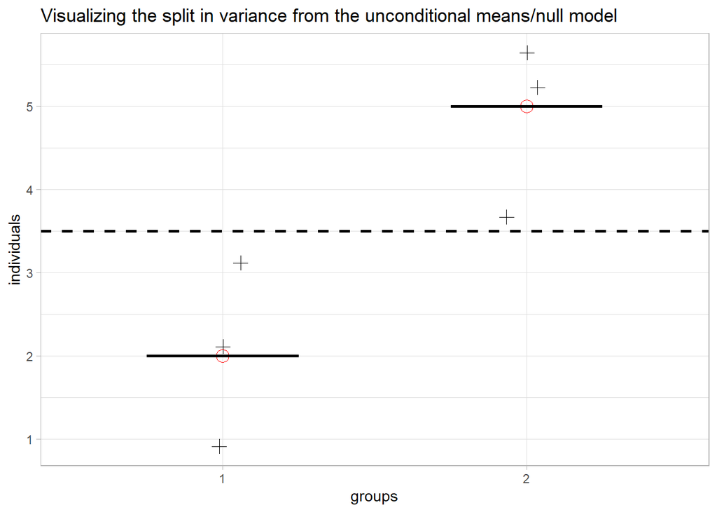

### Exam dataset (Hierarchical data)

We can now move to creating/fitting an unconditional model on a hierarchical dataset in R. Following the examples of the textbook, we are going to load in the ‘Exam’ data from the “mlmRev” packaged.

```r
# Load in the pacakage
library(mlmRev)

# Load in the data
data(Exam)
```

- There are 4059 rows in the Exam dataset
- The variable school contains 65 unique schools

Let’s view the first 6 rows.

```r
# View the first 6 rows
head(Exam) %>%
  kbl(caption = "First 6 rows of the Exam hierarchical data") %>%
  kable_paper(full_width = F)
```

First 6 rows of the Exam hierarchical data

| school | normexam | schgend | schavg | vr | intake | standLRT | sex | type | student |
| --- | --- | --- | --- | --- | --- | --- | --- | --- | --- |
| 1 | 0.2613242 | mixed | 0.1661752 | mid 50% | bottom 25% | 0.6190592 | F | Mxd | 143 |
| 1 | 0.1340672 | mixed | 0.1661752 | mid 50% | mid 50% | 0.2058022 | F | Mxd | 145 |
| 1 | -1.7238820 | mixed | 0.1661752 | mid 50% | top 25% | -1.3645760 | M | Mxd | 142 |
| 1 | 0.9675862 | mixed | 0.1661752 | mid 50% | mid 50% | 0.2058022 | F | Mxd | 141 |
| 1 | 0.5443412 | mixed | 0.1661752 | mid 50% | mid 50% | 0.3711052 | F | Mxd | 138 |
| 1 | 1.7348992 | mixed | 0.1661752 | mid 50% | bottom 25% | 2.1894372 | M | Mxd | 155 |

To get a better look of what our data consists, we can use the ‘glimpse’ function.

```r
glimpse(Exam)
```

```
Rows: 4,059
Columns: 10
$ school   <fct> 1, 1, 1, 1, 1, 1, 1, 1, 1, 1, 1, 1, 1, 1, 1, 1, 1, 1, 1, 1, 1…
$ normexam <dbl> 0.2613242, 0.1340672, -1.7238820, 0.9675862, 0.5443412, 1.734…
$ schgend  <fct> mixed, mixed, mixed, mixed, mixed, mixed, mixed, mixed, mixed…
$ schavg   <dbl> 0.1661752, 0.1661752, 0.1661752, 0.1661752, 0.1661752, 0.1661…
$ vr       <fct> mid 50%, mid 50%, mid 50%, mid 50%, mid 50%, mid 50%, mid 50%…
$ intake   <fct> bottom 25%, mid 50%, top 25%, mid 50%, mid 50%, bottom 25%, t…
$ standLRT <dbl> 0.6190592, 0.2058022, -1.3645760, 0.2058022, 0.3711052, 2.189…
$ sex      <fct> F, F, M, F, F, M, M, M, F, M, M, M, M, M, M, F, F, M, M, F, F…
$ type     <fct> Mxd, Mxd, Mxd, Mxd, Mxd, Mxd, Mxd, Mxd, Mxd, Mxd, Mxd, Mxd, M…
$ student  <fct> 143, 145, 142, 141, 138, 155, 158, 115, 117, 113, 112, 137, 1…
```

Our outcome of interest for this dataset is ‘normexam’. This is the student’s standardized exam score. Standardized in this case means they are z-scores, with the mean equaling close to zero and the standard deviation being equal close to 1.

```r
# Load in the psych package
library(psych)

# Use the describe function on the outcome variable
round(data.frame(describe(Exam$normexam)),2) %>%
  kbl(caption = "Outcome variable descriptive statistics") %>%
  kable_paper(full_width = F)
```

Outcome variable descriptive statistics

|  | vars | n | mean | sd | median | trimmed | mad | min | max | range | skew | kurtosis | se |
| --- | --- | --- | --- | --- | --- | --- | --- | --- | --- | --- | --- | --- | --- |
| X1 | 1 | 4059 | 0 | 1 | 0 | 0 | 1 | -3.67 | 3.67 | 7.33 | 0 | -0.02 | 0.02 |

### Fitting the unconditional/null model on the Exam data set

This might be kind of odd, but we will now be fitting a model of this data with no predictors. As mentioned, the goal of doing this will be to obtain the variance of group-level and within-level and to use this as a baseline for later comparisons with models that include predictors. Also, it is important to mention that this unconditional/null model is also called the **unconditional random intercept model**.

The code to run a multilevel model is called the ‘lmer’ function which comes in the lmerTest package. Even though we say there are no predictors in the model, what that really means mathematically and code wise is that we are only using the intercept as a predictor. Additionally, we need to specify what our random effects are. While I am not 100% sure what this means, it seems that we want this to apply to group variables, such as school. Doing this will allow all scores/individuals within schools to produce regression lines with the same slope but with different y-intercepts. Code wise, this part is programmed with the (1|school) argument, where 1 indicates that we want to the intercepts to vary randomly and school is the name of the group/cluster variable of interest.

```r
# Load in the lmerTest package
library(lmerTest)

# Run an unconditional/null model/unconditional random intercept model
null.model <- lmer(normexam ~ 1 + (1|school), Exam)
```

Above we saved the null model as an object called ‘null.model’, now we can use the summary function to obtain information about our model. What we are most interested in is the variance portion, which is mentioned under ‘Random effects:’ We can see that there is a column named variance, the values below indicate the variance for the group-level ($\tau_{00}$ = .172) and the individual-level ($\sigma^2$ = .848). We can also use the section right underneath to double check the number of observations (4059) and the number of schools (65) that the model was fitted on. These components of variance are going to function as a baseline of variance for future models that include predictors. The idea is that the inclusion of predictors will reduce the variance, since some of it can start to be explained. If including predictors does not decrease the variance much, then we can conclude that they are not very good and neither is the model.

```r
# Print out the summary of the model
summary(null.model)
```

```
Linear mixed model fit by REML. t-tests use Satterthwaite's method [
lmerModLmerTest]
Formula: normexam ~ 1 + (1 | school)
   Data: Exam

REML criterion at convergence: 11014.7

Scaled residuals:
    Min      1Q  Median      3Q     Max
-3.9471 -0.6491  0.0117  0.6987  3.6572

Random effects:
 Groups   Name        Variance Std.Dev.
 school   (Intercept) 0.1716   0.4142
 Residual             0.8478   0.9207
Number of obs: 4059, groups:  school, 65

Fixed effects:
            Estimate Std. Error       df t value Pr(>|t|)
(Intercept) -0.01325    0.05405 62.52893  -0.245    0.807
```

### Computing the intraclass correlation coefficient (ICC)

The last thing we want to do is calculate the **intraclass correlation coefficient (ICC)** or p (“rho”). This is also known as the variance partition coefficient. This can only be calculated from the null model. It basically tells you the proportion of variance of the outcome that can be explained by grouping-level or level-2 unit variables. The ICC can also be interprested as the similarity between two subjects when they are randomly selected from the same group. Thus, the higher the ICC, then the more group is a stronger predictor of the outcome or the more similar subjects within a group are compared to another group. The formulat to calculate the ICC is very simple and shown below.

$$\begin{align*}
ICC = \frac{\tau_{00}} {\tau_{00} + \sigma^2} = \frac{.172}{.172 + .848}
= .169
\end{align*}$$

These notation are not new, $\tau_{00}$ represents the variance of the outcome variable partitioned by group and $\sigma^2$ is the partitioned variance represented by individuals. Thus, we take the variance explained by group and divide it by the sum of its variance with the variance of individuals and that produces the ICC. In the Exam dataset, the ICC is .169, which means that is how much variance is explained by grouping. It can also be written as “16.9% of the variance in the outcome can be attributed to school-level factors.” This can be calculated easily by hand or you can also use the icc function from the performance packaged to double check.

```r
# Calculate the ICC
performance::icc(null.model)
```

```
# Intraclass Correlation Coefficient

    Adjusted ICC: 0.168
  Unadjusted ICC: 0.168
```

Since the ICC is measuring how much grouping can explain variance in the outcome, then it may reasoned that a very low iCC (.01) would indicate the MLM is not needed. This is not always the case!

### Understanding the ICC further

The ICC is a value that ranges from 0 to 1. 0 indicates that there is no effect of group (group means are not good for explaining variance), which means that if you were to calculate the groups means and compare them, they would all be pretty similar to each other. Additionally, if you were to compare each individual score within each group to each other, that is where the variation would be. On the otherhand, if the ICC was the value of 1, then that would mean that when comparing group means to each other, they would all be pretty different and the variation of individual scores within each group would be similar or the same.

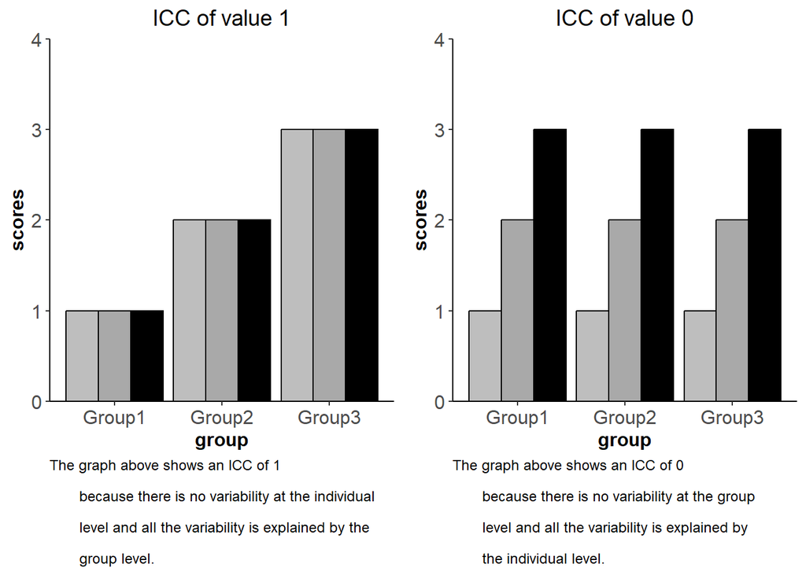

# Chapter 3: Adding Predictors to a Random Intercept Model

We will now continue with the same dataset from the previous chapter (Exam) and introduce predictors. Let’s start by first visualizing the notation of a MLM when a level-1 predictor is included. For the Exam dataset, let’s do this for the variable ‘standLRT’, which is the standardized London Reading Test. Again, our outcome variable is ‘normexam’, which is the standardized scores on some exam. Including this predictor in notation would look like the following:

**Level 1:** We can make-out some important information from the symbols present and the subscripts as well. In continuation to what we covered in Chapter 2, the i subscript represents individual scores and j represents the group that the scores are within. Starting from left to right, the Y variable represents the scores of the outcome (‘normexam’) and it’s equal to the intercept ($\beta_{0j}$) which varies in value based on group j + the slope ($\beta_{1j}$) of the first predictor ‘standLRT’ which also varies by group j + any error $r_{ij}$ that the model does not capture.

$$\begin{align*}
Y_{ij} = \beta_{0j} + \beta_{1j}standLRT_{ij} + r_{ij}
\end{align*}$$

**Level 2:** Unfortunately, the textbook does not explain these formulas clearly, just provides them. We can infer that as before, the intercept used in the equation for level 1 ($\beta_{0j}$) is equal to the grand mean of the outcome variable ($\gamma_{00}$) plus the difference of the observed Y values from j group means respectively ($u_{0j}$).Unsure about what $\gamma_{10}$ means. It may be related to it being a fixed effect. For example, in Chapter 2, while not mentioned but confirmed in [centerstat.org](https://centerstat.org/wp-content/uploads/2021/08/MLM-Chapter-2-Notes-2021.pdf), the grand mean of the outcome variable ($\gamma_{00}$) functioned as the fixed effect while $u_{0j}$ and $r_{ij}$ functioned as the group-level and individual-level random effect. Thus, using gamma with the subscript 10 can indicate to the reader that this is the fixed effect for the first predictor. If this interpretation is correct, then we will predict that the inclusion of a second level-1 predictor will result in this notation $\gamma_{20}$

$$\begin{align*}
\beta_{0j} = \gamma_{00} + u_{0j}
\end{align*}$$

$$\begin{align*}
\beta_{1j} = \gamma_{10}
\end{align*}$$

**Combining equations:** The combined equation gives us the clearest understading of what is going on. This is not confirmed in the book but an interpretation from what makes sense to me. Again, starting from left to right, Y represents scores of the outcome variable while keeping track of each individual in each j group. The outcome is equal to $\gamma_{00}$, which is the grand mean of the outcome variable and a fixed effect. By this notation it is probably functioning as the y-intercept of the model. Next is $\gamma_{10}$, which is another fixed effect. Notice this is infront of the predictor ‘standLRT’, so that means $\gamma_{10}$ is functioning as the slope of the model and it is **not** changing. Lastly, what follows in the model are the random effects of the group-level ($u_{0j}$) and the individual-level ($r_{ij}$).

$$\begin{align*}
Y_{ij} = \gamma_{00} + \gamma_{10}standLRT_{ij} + u_{0j} + r_{ij}
\end{align*}$$

### Summary statistics of standLRT

Just like our outcome variable, the predictor standLRT is comprised of standardized scores. This means that the original scores were transformed by taking each score, subtracting it by the mean and then dividing it by the standard deviation. Thus, the outcome is a vector of scores where the mean is equal to 0 and the standard deviation is equal to 1. We can also call these **z-scores** and acknowledge that this is a form of grand mean centering.

Level-1 predictor variable descriptive statistics

|  | vars | n | mean | sd | median | trimmed | mad | min | max | range | skew | kurtosis | se |
| --- | --- | --- | --- | --- | --- | --- | --- | --- | --- | --- | --- | --- | --- |
| X1 | 1 | 4059 | 0 | 0.99 | 0.04 | 0.02 | 0.98 | -2.93 | 3.02 | 5.95 | -0.13 | 0.07 | 0.02 |

### Introducing the predictor into the model (Conditional, random intercept model)

This next code chunk shows the introduction of a level-1 predictor into the model. Time time we will not specify or write in ~1 as we did in the null model since this is by default added in. This means the code will automatically include the intercept as a predictor. Also, the model intuitively knows whether the predictor being added is a level-1 predictor or a level-2, so that does not need to be specified. This model is now called a **conditional, random intercept model**, in which the intercept is allowed to vary by school (1|school).

```r
# Create a new model with one predictor and save it as an object
mod1 <- lmer(normexam ~ standLRT + (1|school), data = Exam)
```

Below is the summary of the model we just created. We set the argument cor = FALSE to prevent printing the Correlation of Fixed Effects which is not meaningful information. For quality control, let’s first compare the Number of observations and Number of groups for each model (mod1 vs null). We see that these are the same so that is a good start. Next, we notice that the variance for group-level (school) and individual-level (Residual) both differ in mod1 compared to null.model. This is interesting because it confirms that the inclusion of a level-1 predictor does not only reduce the variance (error) of the outcome explained by level-1 predictors but also the variance of the outcome that is explained by level-2 predictors. Lastly, mod1 introduces a predictor to the model which is shown under Fixed effects. Here we can see the intercept and standLRT. The estimate (slope of the line or $\gamma_{10}$) is present which is `0.563` and it is statistically significant (p<.05). The degrees of freedom showed are called Satterthwaite degrees of freedom (more information in the textbook). Thus visually we can see not only that introducing standLRT into the model explained some of the variance (had a smaller variance output compare to the null model) but that standLRT was also significant.

To compare models, we will be using the output shown in a [NCRM YouTube video](https://www.youtube.com/watch?v=KmbtZNjvsNM&list=PL-XAd1-IhZXZxcWfV0ErYVwPSvGzZ2Lup&index=2) where the models make up the last two columns and show the fixed effect estimates at the top and the random variance at the bottom. The pseudo R^2 will be calculate in the next section.

The code below is a little complex- essentially we are extracting information that we need from the tidy and VarCorr functions. Then transforming the data to clean and make it more presentable. Then binding this information into an informative data frame. This code is **not** the final version- the final version will be in the next chapter. However, from these output, we can calculate the ICC from the variances reported in the null model and the pseudo R^2 by comparing the variances between model 1 and the null.

```r
# Extract mod1 fixed estimate and random effects
mod1.fixed <- broom.mixed::tidy(mod1, "fixed") %>% select(2:4)
mod1.random <- tibble(as.data.frame(VarCorr(mod1))[,c(1,4:5)])

# Round numbers three points
mod1.fixed2 <- cbind(mod1.fixed[,1], round(mod1.fixed[,2:3],3)) %>% tibble()
mod1.random2 <- cbind(mod1.random[,1], round(mod1.random[,2],3)) %>% tibble()

# Extract the null mod fixed estimate and random effects
null.fixed <- broom.mixed::tidy(null.model, "fixed") %>% select(2:4)
null.random <- tibble(as.data.frame(VarCorr(null.model))[,c(1,4:5)])

# Round numbers three points
null.fixed2 <- cbind(null.fixed[,1], round(null.fixed[,2:3],3)) %>% tibble()
null.random2 <- cbind(null.random[,1], round(null.random[,2],3)) %>% tibble()

# Construct a new table from this information
joined.fixed <- mod1.fixed2[,1] %>%
  left_join(null.fixed2, by = "term") %>%
  left_join(mod1.fixed2, by = "term")

joined.random <- mod1.random2[,1] %>%
  left_join(null.random2, by = "grp") %>%
  left_join(mod1.random2, by = "grp")

# Combining the estimate and standard deviation into one variable
joined.fixed.char <- joined.fixed %>%
  transmute(term,
            estimate.x = ifelse(is.na(estimate.x), NA,
                                paste(estimate.x," (",std.error.x,")",sep ="")),
            estimate.y = ifelse(is.na(estimate.y), NA,
                                paste(estimate.y," (",std.error.y,")",sep ="")))


# Rename the variables for each data frame so we can then stack them together
names(joined.fixed.char) <- c(" ", "Null Model", "Model 1")
names(joined.random) <- c(" ", "Null Model", "Model 1")

# Stack them together into one
joined.fixed.random <- rbind(joined.fixed.char,
                             joined.random)

# Print the information as a nice data table
joined.fixed.random %>%
  kbl(caption = "Random Intercept Model") %>%
  kable_paper(full_width = F) %>%
  pack_rows("Fixed Part", 1, 2) %>%
  pack_rows("Random Part", 3, 4)
```

Random Intercept Model

|  | Null Model | Model 1 |
| --- | --- | --- |
| **Fixed Part** |  |  |
| (Intercept) | -0.013 (0.054) | 0.002 (0.04) |
| standLRT | NA | 0.563 (0.012) |
| **Random Part** |  |  |
| school | 0.172 | 0.094 |
| Residual | 0.848 | 0.566 |

### How much variance is explained at level one? (Calculating pseudo R^2)

The pseudo R^2 functions the same as the typical R^2 reported in regressions. It is a proportion that describes how much of the outcome variable is explained by the predictors. To calculate the pseudo R^2, we take the variance at level 1 from the null model ($\sigma^2_{NULL}$) and then subtract it by the level 1 variance of the predictor model ($\sigma^2_{FULL}$) and subtract it from the former ($\sigma^2_{NULL}$).

$$\begin{align*}
Pseudo R^2 = \frac{\sigma^2_{NULL} - \sigma^2_{FULL}}{\sigma^2_{NULL}}
\end{align*}$$

We can now use this formula to calculate the pseudo R^2 of mod1.

```r
# Obtaining the variance of mod 1
mod1.var <- as.data.frame(VarCorr(mod1))[,c(1,4)]

# Obtaining the variance of the null model
null.model.var <- as.data.frame(VarCorr(null.model))[,c(1,4)]

# join the models variance types
joined.model.var <- mod1.var %>%
  left_join(null.model.var, by = "grp")

# Calculate pseudo R^2
joined.model.var<- joined.model.var %>%
  mutate(vcov.x = round(vcov.x,3),
         vcov.y = round(vcov.y,3),
         PseudoR2 = round((vcov.y - vcov.x)/vcov.y,3))

# Print the data frame
joined.model.var %>%
  kbl(caption = "Pseudo R^2 of mod1 (Residual)") %>%
  kable_paper(full_width = F)
```

Pseudo R^2 of mod1 (Residual)

| grp | vcov.x | vcov.y | PseudoR2 |
| --- | --- | --- | --- |
| school | 0.094 | 0.172 | 0.453 |
| Residual | 0.566 | 0.848 | 0.333 |

- The Pseudo R^2 of mod1 is 0.333. This means that 33.3 % of the variance in normexam is explained by the predictor standLRT. However, this estimate is biased for we did not calculate a pure within group effect.

### Creating and adding level-2 predictors

We will now introduce a level-2 predictor. Except, this level-2 predictor will be one that we will create from our level-1 predictor. We will use the ave function to obtain the mean standLRT for each school in our sample. This function will return a vector the same size as the rows for the data frame Exam, which is needed for us to run the model correctly. Every row apart of the same school should have the same mean score. Thus, when this variable is introduced into the next MLM, the code will know that this will function as a level-2 predictor since there is no within variability in this variable whatsoever (again, each score for each school will be identical). Below we will create the vector and show some descriptive statistics of our level-2 predictor.

When compared to the level-1 standLRT, which has a min of -2.935 and a max of 3.016, the level-2 m.standLRT has a more limited range, with a min of -.756 and a max of .638. This makes sense since these are means, so the scores that make up this variable would be closer to the actual mean of standLRT.

```r
# Create the level-2 predictor
Exam$m.standLRT <- ave(Exam$standLRT, Exam$school)
```

Descriptive statistics of m.standLRT

|  | vars | n | mean | sd | median | trimmed | mad | min | max | range | skew | kurtosis | se |
| --- | --- | --- | --- | --- | --- | --- | --- | --- | --- | --- | --- | --- | --- |
| X1 | 1 | 4059 | 0.002 | 0.315 | -0.02 | 0.012 | 0.319 | -0.756 | 0.638 | 1.394 | -0.203 | -0.347 | 0.005 |

Descriptive statistics of standLRT

|  | vars | n | mean | sd | median | trimmed | mad | min | max | range | skew | kurtosis | se |
| --- | --- | --- | --- | --- | --- | --- | --- | --- | --- | --- | --- | --- | --- |
| X1 | 1 | 4059 | 0.002 | 0.993 | 0.04 | 0.016 | 0.98 | -2.935 | 3.016 | 5.951 | -0.128 | 0.069 | 0.016 |

### Notation of our second model

This model builds on mod1, which includes the level-1 predictor standLRT. Thus, the level one notation stays the same.

**Level 1:** This is the same notation from the previous section.

$$\begin{align*}
Y_{ij} = \beta_{0j} + \beta_{1j}standLRT_{ij} + r_{ij}
\end{align*}$$

**Level 2:** The difference takes place in this part of the formula. Now we have included the variable m.standLRT, a second-level predictor. As mentioned before, the gamma notation ($\gamma_{01}$) infront of the predictor is a fixed effect, so this is likely representing the slope of the line created from this type of predictor. The following part of the code remains unchanged and the group-level random effects ($u_{0j}$) are still present.

$$\begin{align*}
\beta_{0j} = \gamma_{00} + \gamma_{01}m.standLRT_{j}+ u_{0j}
\end{align*}$$

$$\begin{align*}
\beta_{1j} = \gamma_{10}
\end{align*}$$

**combined equations:** Viewing the equation below, we are stating that the outcome variable Y is equal to the first fixed effect ($\gamma_{00}$), which is the grand mean of the outcome ($\bar{Y}$), plus the fixed slope of the level-2 predictor m.standLRT + the fixed slope of the individual-level predictor standLRT. Additionally, the random effects of group ($u_{0j}$) and individual level ($r_{ij}$) remain.

$$\begin{align*}
Y_{ij} = \gamma_{00} + \gamma_{01}m.standLRT_{j} +
\gamma_{10}standLRT_{ij} + u_{0j} + r_{ij}
\end{align*}$$

### Creating the mod2 MLM

Now we will create a new MLM model which includes the level-2 predictor into it. The code for it is below.

```r
# Create the second model
mod2 <- lmer(normexam ~ m.standLRT + standLRT  + (1|school), Exam)
```

We now want to print out the meaningful results of this model and compare it to the last two we created (the null model and mod1). Code has been constructed to do this. First, we need to manually input the models we want to compare into a list- that is shown below.

```r
# Create a list with the models we want to compare - place in order from least complex to most!
# ALWAYS INSERT NULL MODE FIRST
model.list <- list(null.model,
                   mod1,
                   mod2)

# Insert the names of the model as a character
names(model.list) <- c("Null Model",
                       "Model 1",
                       "Model 2")
```

The outcomes should be interpreted as the following: The variable m.standLRT, which is significant, is known as the **contextual** or **composition** effect. The interpretation of this estimate is that when controlling for the effects of standLRT (having a sub group of individuals with the same standLRT scores), that being in a school with a one point higher m.standLRT will lead to an increase in the outcome (normexam) by .3577. Conversely, when interpreting standLRT, this is saying that after controlling for the effects of m.standLRT (aka, everyone in this sample all went to the same school), that having a one-point increase in standLRT led to an increase in the outcome by .5595. Thus the estimate of the latter can be interpreted as the **pure-within group effect** ($\gamma_{10}$).

When comparing the estimates for standLRT between mod1 (no group predictor) and mod2 (group predictor), we can see that they are pretty similar. This will not always be case.

The code below is almost done- it just needs to include p-values and then it will be finalized! But overall this is a very good start.

```r
# Create two empty lists, one to save fixed effects and the other to save random effects
fixed.effects.list <- list()
random.effects.list <- list()

# Run a for loop to extract the following from each model: 1) Fixed Estimates; 2) Random Effects
for(ii in 1:length(model.list)) {

  # Extract the fixed estimates and random effects
  mod.fixed <- broom.mixed::tidy(model.list[[ii]], "fixed") %>% select(2:4)
  mod.random <- tibble(as.data.frame(VarCorr(model.list[[ii]]))[,c(1,4:5)])

  # Data cleaning: Round numbers three points
  fixed.effects.list[[ii]] <- cbind(mod.fixed[,1], round(mod.fixed[,2:3],3)) %>% tibble()
  random.effects.list[[ii]] <- cbind(mod.random[,1], round(mod.random[,2],3)) %>% tibble()

}

# Merge the lists respectively
fixed.effects <- Reduce(function(x, y) merge(x, y, by="term", all = TRUE), fixed.effects.list)
random.effects <- Reduce(function(x, y) merge(x, y, by="grp", all = TRUE), random.effects.list)

# Create a list to save fixed estimates char
fixed.effects.char.list <- list()

# Combine the estimates and std error columns for fixed effects (will need to create a for loop)
for(ii in 1:length(model.list)) {

  # Assign current estimate and std pair
  cols = c(2*ii, 2*ii + 1)

  # Extract the estimate and std pair
  fixed.effects.pair <- fixed.effects %>%
    select(all_of(cols))

  # Rename these variables so they can be manipulated using the mutate function
  names(fixed.effects.pair) <- c("estimate","std")

  # Mutate them so they can be pasted together
  fixed.effects.char.list[[ii]] <- transmute(fixed.effects.pair, Estimate = ifelse(is.na(estimate),
                                                  "-",
                                                  paste(estimate," (",std,")",sep="")))
}

# Merge the fixed effects char and make a copy for the variance and call it char (This is so we can continue to use the original for other calculations)
fixed.effects.char <- cbind(fixed.effects$term,
                            do.call(cbind,fixed.effects.char.list))

random.effects.char <- random.effects

# Rename the fixed effects and random effects data frames by the models
names(fixed.effects.char) <- c("_", names(model.list))
names(random.effects.char) <- c("_", names(model.list))

# Stack them together into one
stacked.fixed.random <- rbind(fixed.effects.char,
                              random.effects.char)

# Print the information as a nice data table
stacked.fixed.random %>%
  kbl(caption = "Random Intercept Model") %>%
  kable_paper(full_width = F) %>%
  pack_rows("Fixed Part", 1, nrow(fixed.effects.char)) %>%
  pack_rows("Random Part", nrow(fixed.effects.char) + 1 , nrow(fixed.effects.char) + 2)
```

Random Intercept Model

_

Null Model

Model 1

Model 2

**Fixed Part**

(Intercept)

-0.013 (0.054)

0.002 (0.04)

0.012 (0.037)

m.standLRT

0.358 (0.112)

standLRT

0.563 (0.012)

0.559 (0.013)

**Random Part**

Residual

0.848

0.566

0.566

school

0.172

0.094

0.079

We can also use the information created from the objects above to make an additional table with information on model’s performance. This is done by calculating Pseudo R^2, which is a measure of how much variance was explained by the introduction of predictors into the model. We can calculate the Pseudo R^2 for both individual and group-level variance.

```r
# Need to calculate pseudo R^2 for each model by comparing the variance to the null model
pseudo.R2.individual.list <- list()
pseudo.R2.group.list <- list()

for(ii in 1:(length(model.list)-1)) {

  # Filter out the individual and group variance
  individual.variance <- random.effects %>% filter(grp == "Residual")
  group.variance <- random.effects %>% filter(grp == "school")

  # Calculate the PseudoR2 respectively
  pseudo.R2.individual.list[[ii]] <- round((individual.variance[[2]] - individual.variance[[ii+2]])/individual.variance[[2]],3)
  pseudo.R2.group.list[[ii]] <- round((group.variance[[2]] - group.variance[[ii+2]])/group.variance[[2]],3)

}

# Transform the lists into data frames and merge them
PseudoR2.df <- rbind(do.call(cbind,pseudo.R2.individual.list),
                     do.call(cbind,pseudo.R2.group.list)) %>% data.frame()

# Add a name variable
PseudoR2.df2 <- cbind(c("Individual level R^2",
                        "Group level R^2"), PseudoR2.df)

# Rename the data frame
names(PseudoR2.df2) <- c("_", names(model.list)[2:length(model.list)])

# Print out the table
PseudoR2.df2 %>%
  kbl(caption = "Pseudo R^2 for each model") %>%
  kable_paper(full_width = F)
```

Pseudo R^2 for each model

| _ | Model 1 | Model 2 |
| --- | --- | --- |
| Individual level R^2 | 0.333 | 0.333 |
| Group level R^2 | 0.453 | 0.541 |

### Introducing a group mean centered (GPC) level 1 variable

Now that we created the variable, m.standLRT, we can use this to create a group mean centered (GPC) variable from standLRT. This variable is also known as the **centered within context** variable. We can create this variable easily with the code below and introduce it into the Exam dataset.

```r
Exam$standLRT.gpc <- Exam$standLRT - Exam$m.standLRT
```

It is also important to know how this variable is notated in the MLM equation, which is shown below (ex: for **Level 1**).

$$\begin{align*}
Y_{ij} = \beta_{0j} + \beta_{1j}(standLRT_{ij} - m.standLRT_{j}) +
r_{ij}
\end{align*}$$

With this variable created, we can now use it to create a new model with it replacing the original standLRT variable.

```r
mod2.gpc <- lmer(normexam ~ m.standLRT + standLRT.gpc + (1|school), data = Exam)
```

Below is the summary tables of each model (code not shown but is the same as the one from the previous section).

- 1. The regression coefficient and the standard error are the same for standLRT and standLRT.gpc when m.standLRT is included (Note it is different in Model 1).
- 2. The residual variances are the same for both Model 2 and Model 2 (GPC).
- 3. The m.standLRT coefficient is what differs between Model 2 and Model 2 (GPC).

**Contextual effect:** The estimate for m.standLRT in Model 2 functions as the contextual effect.

**Between-group effect:** The estimate for m.standLRT in Model 2 (GPC) functions as the between-group effect.

**Within-group effect:** In both Model 2 and Model 2 (GPC), the estimate for standLRT and standLRT.gpc is the within-group effect.

Random Intercept Model: Predicting exam scores from test performance

_

Null Model

Model 1

Model 2

Model 2 (GPC)

**Fixed Part**

(Intercept)

-0.013 (0.054)

0.002 (0.04)

0.012 (0.037)

0.012 (0.037)

m.standLRT

0.358 (0.112)

0.917 (0.111)

standLRT

0.563 (0.012)

0.559 (0.013)

standLRT.gpc

0.559 (0.013)

**Random Part**

Residual

0.848

0.566

0.566

0.566

school

0.172

0.094

0.079

0.079

Total

1.02

0.66

0.645

0.645

Explaining the results above further (copied directly from the textbook), the **contextual effect** is the difference between two individuals with the same level-1 variables but is different by one unit on the aggregated variable. The **between-group effect** is the expected differences of the group means of the outcome between two groups (i.e., schools) which differ by one unit of m.standLRT (the aggregated predictor at level two).

The between group effect (BG) is the within-group (WG) plus the contextual (C) effect (i.e., WG + C = BG or 0.559 + 0.358 = 0.917). In the same way, the contextual effect is the BG effect less the WG effect (i.e. C = BG - WG or 0.917 - 0.559 = 0.358).

### Reporting Pseudo R^2

The Pseudo R^2 are comparisons to the null model. This is not the only way of doing it. You can also do a comparison of Model 2 (group predictors included) to Model 1 (only level 1 predictor included) and see how much variance is explained at level-2 (this is not what is shown here).

Pseudo R^2 for each model

| _ | Model 1 | Model 2 | Model 2 (GPC) |
| --- | --- | --- | --- |
| Individual level R^2 | 0.333 | 0.333 | 0.333 |
| Group level R^2 | 0.453 | 0.541 | 0.541 |

### Reporting an Overall R^2

A common mistake is to think that the pseudo R^2 functions as an effect size. It is not! What you want to report instead is known as the overall R^2. This is a measure of overall variance accounted for in the outcome by the inclusion of all predictors in a model. To calculate this, we will be using the sum of residual group and individual level variance from the model and dividing it by the sum of residual group and individual level variance from the null then subtracting it from 1. The equation below is what we want to do: The subscript FULL indicates the variance of the model with the predictors (numerator) and the subscript NULL represents the variance of the null model (denominator).

$$\begin{align*}
R^2 = 1 - \frac{\tau_{00.FULL} + \sigma^2_{FULL}}{\tau_{00.NULL} +
\sigma^2_{NULL}} = 1 - \frac{0.645}{1.02} = .37
\end{align*}$$

```r
# extract only the total variance row (This is what we need to calculate Overall R^2)
random.effects.total <- filter(random.effects, grp == "Total")

# Calculate Overall R^2 for each model (not including the null model)
All.models <- random.effects.total[3:length(random.effects.total)]
All.models.R2 <- data.frame(rbind(1 - round(All.models/random.effects.total$vcov1,2)))

# Name the overall R2 data frame
names(All.models.R2) <- names(model.list)[2:length(model.list)]

# Print the data frame as a nice table
All.models.R2 %>%
  kbl(caption = "Overall R^2 for each model") %>%
  kable_paper(full_width = F)
```

Overall R^2 for each model

| Model 1 | Model 2 | Model 2 (GPC) |
| --- | --- | --- |
| 0.35 | 0.37 | 0.37 |

### Introducing Categorical Predictors at Level Two

The Exam dataset includes another group level variable named ‘schgend’. This variable describes the gender of the school as 1) mixed, boys, or girls. It is a group level variable because every row within one school will have the same value for schgend. Below are some descriptive information about this variable. Using the table function gives us an idea of the sample size for each group. Additionally, the table function is really important because the first column (variable) indicates that will function as the reference to the others. Thus, our reference will be ‘mixed’.

```r
str(Exam$schgend)
```

```
 Factor w/ 3 levels "mixed","boys",..: 1 1 1 1 1 1 1 1 1 1 ...
```

```r
table(Exam$schgend)
```

```
mixed  boys girls
 2169   513  1377
```

You can also change the reference group in a factor variable with the code below. We will keep mixed as the reference group for now. You can confirm that this worked by running table again or by looking at your output from the model. What ever group is labeled as the reference will not be present in the output.

```r
Exam$schgend <- relevel(Exam$schgend, ref = 'mixed')
```

### Including schgend variable into the equation

This is a group-level variable so it will be included into the equation for level 2.

**Level 1:**

$$\begin{align*}
Y_{ij} = \beta_{0j} + \beta_{1j}standLRT.gpc_{ij} + r_{ij}
\end{align*}$$

**Level 2:** Notice the introduction of a second group-level variable is notated with gamma subscript increasing by 1. Since this group level variable is categorical and has three levels, it is essentially translated to two additional predictors. Since ‘mixed’ is the reference, it is not present in the equation but it predicts Y in the combined equation when schgend (boys) an schgend (girls) are both equal to 0.

$$\begin{align*}
\beta_{0j} = \gamma_{00} + \gamma_{01}m.standLRT_{j}+
\gamma_{02}schgend(boys)_{j} + \gamma_{03}schgend(girls)_{j} + u_{0j}
\end{align*}$$

$$\begin{align*}
\beta_{1j} = \gamma_{10}
\end{align*}$$

### Creating the model with the Categorical Predictors

```r
mod3 <- lmer(normexam ~ m.standLRT + schgend + standLRT.gpc + (1|school), data  = Exam)
```

Comparing its performance to the other models we have created so far.

Random Intercept Model: Predicting exam scores from test performance

_

Null Model

Model 1

Model 2

Model 2 (GPC)

Model 3

**Fixed Part**

(Intercept)

-0.013 (0.054)

0.002 (0.04)

0.012 (0.037)

0.012 (0.037)

-0.078 (0.048)

m.standLRT

0.358 (0.112)

0.917 (0.111)

0.912 (0.106)

schgendboys

0.115 (0.103)

schgendgirls

0.237 (0.08)

standLRT

0.563 (0.012)

0.559 (0.013)

standLRT.gpc

0.559 (0.013)

0.559 (0.013)

**Random Part**

Residual

0.848

0.566

0.566

0.566

0.566

school

0.172

0.094

0.079

0.079

0.07

Total

1.02

0.66

0.645

0.645

0.636

Pseudo R^2 for each model

| _ | Model 1 | Model 2 | Model 2 (GPC) | Model 3 |
| --- | --- | --- | --- | --- |
| Individual level R^2 | 0.333 | 0.333 | 0.333 | 0.333 |
| Group level R^2 | 0.453 | 0.541 | 0.541 | 0.593 |

```r
# extract only the total variance row (This is what we need to calculate Overall R^2)
random.effects.total <- filter(random.effects, grp == "Total")

# Calculate Overall R^2 for each model (not including the null model)
All.models <- random.effects.total[3:length(random.effects.total)]
All.models.R2 <- data.frame(rbind(1 - round(All.models/random.effects.total$vcov1,2)))

# Name the overall R2 data frame
names(All.models.R2) <- names(model.list)[2:length(model.list)]

# Print the data frame as a nice table
All.models.R2 %>%
  kbl(caption = "Overall R^2 for each model") %>%
  kable_paper(full_width = F)
```

Overall R^2 for each model

| Model 1 | Model 2 | Model 2 (GPC) | Model 3 |
| --- | --- | --- | --- |
| 0.35 | 0.37 | 0.37 | 0.38 |

### MLM results compared to OLS

Will not show the code or the tables here, but in the book it is very clear that if we ran the analysis from Model 3 in OLS, as in we included gender the way we did for MLM that the result would be similar regression coefficients bur **smaller** standard deviations. This is bad because it increases the probability (quite highly) of making type 1 errors. Again, this is a result of the data structure we have. We have group-level variables which represent redudent data. For example, each school has the same value of ‘mixed’, ‘boy’, or ‘girl’, depending on the number of subjects that attend it. This redundant information in the OLS model gives it more power than it should have, which results in smaller standard errors and higher chances of finding false significant findings.

### Should using MLM be optional when ICC is Low?

No. There is an example in textbook where authors investigating deworming medicine effects on weight reported significant differences between groups. These groups (two treatment vs control) were made up of children that belong to different parishes (churches), which means the data structure was hierarchical. Their results showed that using deworming medicine led to statistically significant weight gain compared to controls. However, later the paper had to be correct for because when the clustering was introduced into the model (they used MLM) the results were no longer significant. Interesting, the ICC was low too (.014) yet it made a big difference on whether the results were significant or not.

### Chapter 3 Test Yourself

(copied directly from the textbook) Building off the model in the Test Yourself section of the last chapter using Hsb82 dataset in the mlmRev package, add meanses (average socioeconomic status [ses] at the school) to the random intercept model predicting mAch with school as the cluster variable.

```r
null.model <- lmer(mAch~ 1 + (1|school),data = Hsb82)
mod1 <- lmer(mAch ~ meanses + (1|school), data = Hsb82)
mod2 <- lmer(mAch ~ meanses + ses + (1|school), data = Hsb82)
mod2.gpc <- lmer(mAch ~ meanses + cses + (1|school), data = Hsb82)
```

Random Intercept Model: Predicting math scores from SES variables

_

Null Model

Model 1

Model 2

Model 2 (GPC)

**Fixed Part**

(Intercept)

12.637 (0.244)

12.685 (0.149)

12.683 (0.149)

12.683 (0.149)

cses

2.191 (0.109)

meanses

5.864 (0.361)

3.675 (0.378)

5.866 (0.362)

ses

2.191 (0.109)

**Random Part**

Residual

39.148

39.157

37.019

37.019

school

8.614

2.639

2.693

2.693

Total

47.762

41.796

39.712

39.712

Pseudo R^2 for each model

| _ | Model 1 | Model 2 | Model 2 (GPC) |
| --- | --- | --- | --- |
| Individual level R^2 | 0.000 | 0.054 | 0.054 |
| Group level R^2 | 0.694 | 0.687 | 0.687 |

Overall R^2 for each model

| Model 1 | Model 2 | Model 2 (GPC) |
| --- | --- | --- |
| 0.12 | 0.17 | 0.17 |

# Chapter 4: Investigating cross-level interactions and random slope models

We are now going to switch to a more advance topic which is investigating interactions. We will do this with the Exam dataset and build upon the MLM models we created for the Exam data set. The code for the refresher are below.

```r
library(lmerTest) # lmer function with p-values
library(mlmRev) # Exam dataset
data(Exam)
Exam$m.standLRT <- ave(Exam$standLRT, Exam$school) # means per group
Exam$standLRT.gpc <- Exam$standLRT - Exam$m.standLRT
mod3 <- lmer(normexam ~ m.standLRT + schgend + standLRT.gpc + (1|school), data = Exam)
```

We are really interested in making changed to Model 3, which investigate if the gender of students in a school (“mixed”, “boys”, or “girls”) may moderate the relationship of out level-1 standLRT.gpc and the outcome normexam. Another way of asking this questions is if there is an interaction between schgend and standLRT.gpc. We can notate an interaction by the following. What gets modified is the second part of level 2. Here we place the predictors for schgend at the bottom and change gamma from 02 and 03 to 11 and 12 respectively. Thus, having a predictor with a gamma in the 10’s indicates that they are being used to test for an interaction.

**Level 1:**

$$\begin{align*}
Y_{ij} = \beta_{0j} + \beta_{1j}standLRT.gpc_{ij} + r_{ij}
\end{align*}$$

**Level 2:** Notice that when we are investigating interaction effects we keep the same notation as we would with main effects but also include the predictors we want to investigate as moderators to the second part of level 2.

$$\begin{align*}
\beta_{0j} = \gamma_{00} + \gamma_{01}m.standLRT_{j}+
\gamma_{02}schgend(boys)_{j} + \gamma_{03}schgend(girls)_{j} + u_{0j}
\end{align*}$$

$$\begin{align*}
\beta_{1j} = \gamma_{10} + \gamma_{11}schgend(boys)_{j} +
\gamma{12}schgend(girls)_{j}
\end{align*}$$

**Combined Equation:** Using the equations from level 1 and level 2 and combining them results in the equation below. Notice how now the additions are replaced to multiplications. Also notice how this gives us a hint on how to enter the variables into a MLM in R. Also not note, this time in th begining we express the categorical ‘schgend’ generally without specifying the type of group.

$$\begin{align*}
Y_{ij} = \gamma_{00} + \gamma_{01}m.standLRT_{j}+ \gamma_{02}schgend_{j}
+ \gamma_{10}standLRT.gpc_{ij} + \gamma_{11}schgend(boys)_{j} x
standLRT.gpc_{ij} + \gamma{12}schgend(girls)_{j} x standLRT.gpc_{ij} +
u_{0j} + r_{ij}
\end{align*}$$